# Análisis 15 Mayo SIR

# Filtremos por unidad geográfica:

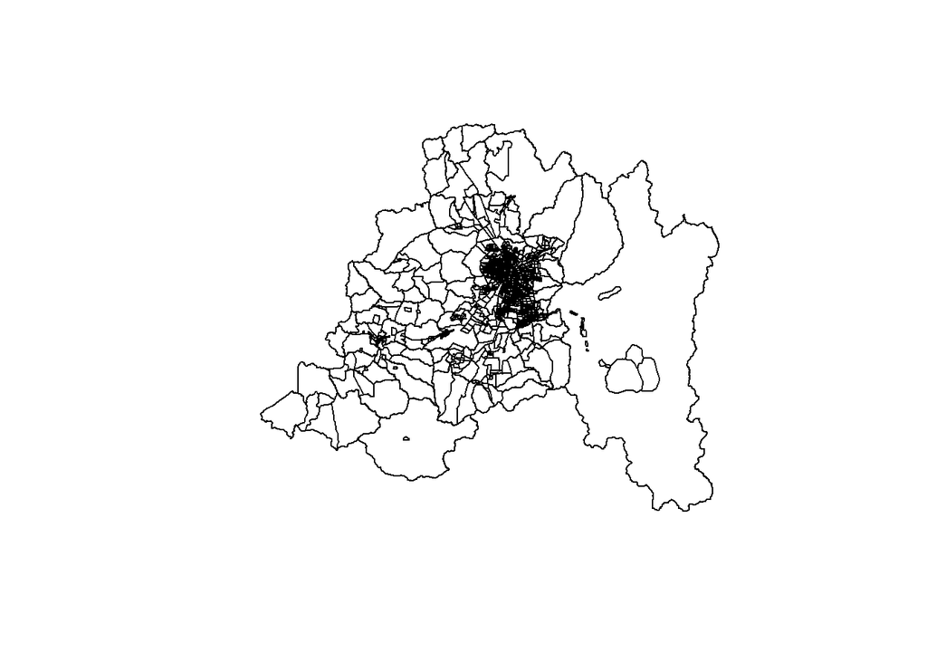

```r
Tarapaca_municipios = CL_comunas %>% filter(T_REG_NOM == "TARAPACA")
plot(st_geometry(Metropolitana_municipios))
```

Uniendo el shapefile al dataframe

Esto se puede hacer utilizando la función left_join() del paquete dplyr. La unión se basará en la columna común compartida por ambos conjuntos de datos, que sería la columna Región.

Primero, necesito poner en minúscula el encabezado de la columna ‘Region’ en el dataset Tarapaca_covid19 y reemplazar el nombre T_REG_NOM por ‘region’ en el dataset de los shp. Esto, para que puedan coincidir las columnas ‘Región’ de ambos datasets.

Luego, hay que llevar a minúsculas la columna ‘Región’ en ambos datasets.

```r
colnames(Tarapaca_covid19)
```

```
##  [1] "Region"                "Comuna"                "Codigo_comuna"
##  [4] "Fec"                   "Fecha"                 "Clave"
##  [7] "Casos_Diarios"         "Casos_Acumulados"      "acumulados_corregidos"
## [10] "Muertes"               "Casos_Activos"         "activos_corregidos"
## [13] "Recuperados"           "Recuperados_Diarios"   "Dia"
## [16] "Fallecidos_Diarios"    "on-off"                "Max_Dia"
```

```r
colnames(Tarapaca_municipios)
```

```
##  [1] "T_REG_CA"   "T_REG_NOM"  "T_PROV_CA"  "T_PROV_NOM" "T_COM"
##  [6] "COMUNA"     "T_COM_NOM"  "T_UV_COD"   "ID_UV"      "T_UV_NOM"
## [11] "geometry"
```

```r
names(Tarapaca_covid19)[names(Tarapaca_covid19) == 'Region'] <- 'region'
names(Tarapaca_municipios)[names(Tarapaca_municipios) == 'T_REG_NOM'] <- 'region'
Tarapaca_covid19$region<-tolower(Tarapaca_covid19$region)#Makes all rows in the county column lowercase
Tarapaca_municipios$region<-tolower(Tarapaca_municipios$region)

#Ahora puedo unir los dos datasets basado en la columna 'region' de ambos.

Tarapaca_covid19_shapes<-left_join(Tarapaca_covid19,Tarapaca_municipios,by="region",all.x = TRUE)%>%
dplyr::select(Fecha,Comuna,region,Casos_Acumulados,geometry)#selects only the columns of interest

#head(Tarapaca_covid19_shapes)
head(Tarapaca_covid19_shapes)
```

```
## # A tibble: 6 x 5
##   Fecha      Comuna  region Casos_Acumulados                            geometry
##   <date>     <chr>   <chr>             <dbl>                  <MULTIPOLYGON [°]>
## 1 2020-03-23 Iquique tarap~                4 (((-69.25363 -20.12262, -69.25361 ~
## 2 2020-03-23 Iquique tarap~                4 (((-69.2535 -20.12259, -69.2418 -2~
## 3 2020-03-23 Iquique tarap~                4 (((-69.01007 -20.67646, -69.00497 ~
## 4 2020-03-23 Iquique tarap~                4 (((-68.97833 -19.93333, -68.97658 ~
## 5 2020-03-23 Iquique tarap~                4 (((-69.47563 -20.40196, -69.47574 ~
## 6 2020-03-23 Iquique tarap~                4 (((-69.74089 -20.26079, -69.70897 ~
```

```r
#Hacer un mapa con ggplot2 y gganimate

#Toda la parte de manipulación de datos está hecha, ahora puedo comenzar a construir el mapa real. Usaré el paquete ggplot2 junto con el paquete gganimate para crear el mapa final de la serie animada que muestra cómo se extendió el covid19 en la región de Tarapacá.

# Used to make new data frame an sf object
# Must use st_as_sf in order to use geom_sf() to plot polygons

library(ggplot2) #Used for plotting
library(gganimate) #Used for animations
library(RColorBrewer)

Tarapaca_covid19_shapes<-st_as_sf(Tarapaca_covid19_shapes)
# Makes plot with ggplot2 and gganimate to animate through the days
covid_map<-ggplot()+
  geom_sf(data = Tarapaca_municipios,fill = "white")+
  geom_sf(data = Tarapaca_covid19_shapes,aes(fill=Casos_Acumulados))+
  ggtitle("Expansión del COVID-19 en la región de Tarapacá")+
  xlab("")+
  ylab("")+
  labs(subtitle = "Date: {current_frame}",
       caption = "Fuente de datos: DataIntelligence\nAutor: Christian Castro")+
  cowplot::background_grid(major = "none", minor = "none") +
  theme(axis.text.x = element_blank(), axis.ticks.x = element_blank(),
        axis.text.y = element_blank(), axis.ticks.y = element_blank(),
        axis.line = element_blank(),
        legend.background = element_blank(),
        legend.position=c(-0.3,0.8),
        plot.background = element_blank(),
        panel.background = element_blank(),
        legend.text = element_text(size=12),
        legend.title = element_text(colour="black", size=12, face="bold"),
        plot.title=element_text(size=20, face="bold",hjust =0.5),
        plot.subtitle = element_text(hjust = 0.5,size=12),
        plot.caption = element_text(size = 11,
                                    hjust = .5,
                                    color = "black",
                                    face = "bold"))+
  scale_fill_distiller("Casos_Acumulados",
                       palette ="Reds",type = "div",
                       direction = 1)+transition_manual(Fecha)
```

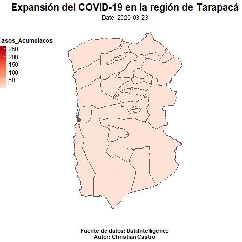

```r
animate(covid_map, nframe=27,fps = 2, end_pause = 15,height = 500, width =500)
```